# IE 423 Project Part 1

**IE 423 PROJECT PART 1**

ULUÇ ALİ BAŞKURT 2021402270

ZEYNEP TALAN 2017402003

In the following project, 6 company's stock prices data are examined in 2 years period in terms of their changing price data. The investigated stocks are AEFES, ARCLK, THYAO, YKBNK, EREGL and TUPRS. Their data is investigated in with quality control with the programming language Python. Several packages and modules are used which are shown below. Boxplots and control charts are created and used in order to determine the outliers and Google Trends search history data is used in order to look for relationship between the stock prices and internet searches to look for root causes and cross checking.

```python
import pandas as pd
```

```python
# we start our task by importing the os modue to retrieve the data in the csv file in an easier fashion

import os

username = 'ulucbaskurt'
file_name = 'all_ticks_wide.csv'
desktop_path = f'/Users/ulucbaskurt/Desktop/'
file_path = os.path.join(desktop_path, file_name)
```

```python
import pandas as pd

# Read the CSV file
data = pd.read_csv(f'/Users/ulucbaskurt/Desktop/all_ticks_wide.csv')

# Now we can work with the data, firstly we put the head command to get a sense of the data
print(data.head())
```

```
              timestamp    AEFES   AKBNK    AKSA  AKSEN   ALARK   ALBRK  \
0  2012-09-17T06:45:00Z  22.3978  5.2084  1.7102   3.87  1.4683  1.1356
1  2012-09-17T07:00:00Z  22.3978  5.1938  1.7066   3.86  1.4574  1.1275
2  2012-09-17T07:15:00Z  22.3978  5.2084  1.7102    NaN  1.4610  1.1356
3  2012-09-17T07:30:00Z  22.3978  5.1938  1.7102   3.86  1.4537  1.1275
4  2012-09-17T07:45:00Z  22.5649  5.2084  1.7102   3.87  1.4574  1.1356

    ANACM   ARCLK   ASELS  ...   TTKOM  TUKAS    TUPRS    USAK   VAKBN  VESTL  \
0  1.0634  6.9909  2.9948  ...  4.2639   0.96  29.8072  1.0382  3.8620   1.90
1  1.0634  6.9259  2.9948  ...  4.2521   0.96  29.7393  1.0382  3.8529   1.90
2  1.0679  6.9909  2.9855  ...  4.2521   0.97  29.6716  1.0463  3.8436   1.91
3  1.0679  6.9584  2.9855  ...  4.2521   0.97  29.7393  1.0382  3.8529   1.91
4  1.0725  6.9909  2.9760  ...  4.2521   0.97  29.8072  1.0382  3.8620   1.90

    YATAS   YKBNK   YUNSA   ZOREN
0  0.4172  2.5438  2.2619  0.7789
1  0.4229  2.5266  2.2462  0.7789
2  0.4229  2.5266  2.2566  0.7789
3  0.4286  2.5324  2.2619  0.7860
4  0.4286  2.5324  2.2619  0.7789

[5 rows x 61 columns]
```

```python
import pandas as pd

# Assuming you have already read your CSV data into the 'a' DataFrame

# Select 3 stocks for analysis
selected_stocks = ['AEFES', 'ARCLK', 'THYAO']

# Create a list to store information about outliers and statistics
outliers_info = []

for stock_name in selected_stocks:
    # Extract the data for the selected stock
    stock_data = a[['timestamp', stock_name]]

    # Convert the 'timestamp' column to a datetime object
    stock_data['timestamp'] = pd.to_datetime(stock_data['timestamp'])

    # Group the data by month and calculate the monthly mean and standard deviation
    monthly_stats = stock_data.groupby(stock_data['timestamp'].dt.to_period('M')).agg({stock_name: ['mean', 'std']})
    monthly_stats.columns = ['Mean', 'Std']

    # Calculate the lower and upper bounds for outlier detection
    monthly_stats['Lower Bound'] = monthly_stats['Mean'] - 3 * monthly_stats['Std']
    monthly_stats['Upper Bound'] = monthly_stats['Mean'] + 3 * monthly_stats['Std']

    # Identify and flag data points that are outliers
    outliers = stock_data.merge(monthly_stats, left_on=stock_data['timestamp'].dt.to_period('M').dt.to_timestamp(), right_on=monthly_stats.index.to_timestamp(), how='left')
    outliers['Outlier'] = (outliers[stock_name] < outliers['Lower Bound']) | (outliers[stock_name] > outliers['Upper Bound'])

    # Filter the rows with outliers
    outlier_rows = outliers[outliers['Outlier']]

    # Store information about outliers and statistics
    for idx, row in outlier_rows.iterrows():
        outliers_info.append({
            'Stock': stock_name,
            'Month': row['timestamp'].strftime('%Y-%m'),
            'Outlier': row[stock_name],
            'Mean': row['Mean'],
            'Std': row['Std']
        })

# Display information about outliers and statistics
for info in outliers_info:
    print(f"Stock: {info['Stock']}, Month: {info['Month']}, Outlier: {info['Outlier']}, Mean: {info['Mean']}, Std: {info['Std']}")
```

```
Stock: AEFES, Month: 2012-12, Outlier: 22.147, Mean: 21.537774759152217, Std: 0.19918620428024103
Stock: AEFES, Month: 2012-12, Outlier: 22.147, Mean: 21.537774759152217, Std: 0.19918620428024103
Stock: AEFES, Month: 2012-12, Outlier: 22.147, Mean: 21.537774759152217, Std: 0.19918620428024103
Stock: AEFES, Month: 2012-12, Outlier: 22.147, Mean: 21.537774759152217, Std: 0.19918620428024103
Stock: AEFES, Month: 2012-12, Outlier: 22.2307, Mean: 21.537774759152217, Std: 0.19918620428024103
Stock: AEFES, Month: 2012-12, Outlier: 22.147, Mean: 21.537774759152217, Std: 0.19918620428024103
Stock: AEFES, Month: 2012-12, Outlier: 22.147, Mean: 21.537774759152217, Std: 0.19918620428024103
Stock: AEFES, Month: 2013-03, Outlier: 24.6543, Mean: 22.979965680473374, Std: 0.48040577389800687
Stock: AEFES, Month: 2013-03, Outlier: 24.5707, Mean: 22.979965680473374, Std: 0.48040577389800687
Stock: AEFES, Month: 2013-03, Outlier: 24.5707, Mean: 22.979965680473374, Std: 0.48040577389800687
Stock: AEFES, Month: 2013-03, Outlier: 24.4872, Mean: 22.979965680473374, Std: 0.48040577389800687
Stock: AEFES, Month: 2013-03, Outlier: 24.5707, Mean: 22.979965680473374, Std: 0.48040577389800687
Stock: AEFES, Month: 2013-03, Outlier: 24.5707, Mean: 22.979965680473374, Std: 0.48040577389800687
Stock: AEFES, Month: 2013-03, Outlier: 24.6543, Mean: 22.979965680473374, Std: 0.48040577389800687
Stock: AEFES, Month: 2013-03, Outlier: 24.6543, Mean: 22.979965680473374, Std: 0.48040577389800687
Stock: AEFES, Month: 2013-03, Outlier: 24.7379, Mean: 22.979965680473374, Std: 0.48040577389800687
Stock: AEFES, Month: 2013-03, Outlier: 24.7379, Mean: 22.979965680473374, Std: 0.48040577389800687
Stock: AEFES, Month: 2013-03, Outlier: 24.6543, Mean: 22.979965680473374, Std: 0.48040577389800687
Stock: AEFES, Month: 2013-03, Outlier: 24.6543, Mean: 22.979965680473374, Std: 0.48040577389800687
Stock: AEFES, Month: 2013-03, Outlier: 24.6543, Mean: 22.979965680473374, Std: 0.48040577389800687
Stock: AEFES, Month: 2013-03, Outlier: 24.6543, Mean: 22.979965680473374, Std: 0.48040577389800687
Stock: AEFES, Month: 2013-05, Outlier: 0.0001, Mean: 25.780976573426575, Std: 1.5789854562040238
Stock: AEFES, Month: 2013-06, Outlier: 25.6934, Mean: 22.484484877126654, Std: 1.0264558000740691
Stock: AEFES, Month: 2013-12, Outlier: 18.8111, Mean: 20.765251819757367, Std: 0.6210266167255477
Stock: AEFES, Month: 2014-04, Outlier: 21.8393, Mean: 23.717965377532227, Std: 0.5360515485915598
Stock: AEFES, Month: 2014-04, Outlier: 21.7476, Mean: 23.717965377532227, Std: 0.5360515485915598
Stock: AEFES, Month: 2014-04, Outlier: 21.7476, Mean: 23.717965377532227, Std: 0.5360515485915598
Stock: AEFES, Month: 2014-04, Outlier: 21.8393, Mean: 23.717965377532227, Std: 0.5360515485915598
Stock: AEFES, Month: 2014-04, Outlier: 22.0228, Mean: 23.717965377532227, Std: 0.5360515485915598
Stock: AEFES, Month: 2014-10, Outlier: 24.7758, Mean: 23.85532257425743, Std: 0.2962286720025203
Stock: AEFES, Month: 2015-08, Outlier: 18.2391, Mean: 19.62701037567084, Std: 0.4339843264760997
Stock: AEFES, Month: 2016-01, Outlier: 13.4782, Mean: 16.690249409780776, Std: 0.6261687629543825
Stock: AEFES, Month: 2016-04, Outlier: 19.5861, Mean: 20.4275516025641, Std: 0.27821468066360444
Stock: AEFES, Month: 2016-04, Outlier: 19.5674, Mean: 20.4275516025641, Std: 0.27821468066360444
Stock: AEFES, Month: 2016-05, Outlier: 20.2969, Mean: 18.13585328, Std: 0.7030598158340888
Stock: AEFES, Month: 2016-05, Outlier: 20.3904, Mean: 18.13585328, Std: 0.7030598158340888
Stock: AEFES, Month: 2016-05, Outlier: 20.5588, Mean: 18.13585328, Std: 0.7030598158340888
Stock: AEFES, Month: 2016-05, Outlier: 20.3343, Mean: 18.13585328, Std: 0.7030598158340888
Stock: AEFES, Month: 2016-05, Outlier: 20.4653, Mean: 18.13585328, Std: 0.7030598158340888
Stock: AEFES, Month: 2016-05, Outlier: 20.4839, Mean: 18.13585328, Std: 0.7030598158340888
```

[output cut: 182 more lines]

```
Stock: THYAO, Month: 2017-02, Outlier: 5.46, Mean: 5.678612903225807, Std: 0.0713022995908071
Stock: THYAO, Month: 2018-08, Outlier: 14.65, Mean: 16.74861367837338, Std: 0.6870835577235476
Stock: THYAO, Month: 2018-08, Outlier: 14.35, Mean: 16.74861367837338, Std: 0.6870835577235476
Stock: THYAO, Month: 2018-08, Outlier: 14.48, Mean: 16.74861367837338, Std: 0.6870835577235476
Stock: THYAO, Month: 2018-08, Outlier: 14.67, Mean: 16.74861367837338, Std: 0.6870835577235476
Stock: THYAO, Month: 2018-08, Outlier: 14.62, Mean: 16.74861367837338, Std: 0.6870835577235476
Stock: THYAO, Month: 2018-08, Outlier: 14.57, Mean: 16.74861367837338, Std: 0.6870835577235476
Stock: THYAO, Month: 2018-08, Outlier: 14.6, Mean: 16.74861367837338, Std: 0.6870835577235476
Stock: THYAO, Month: 2018-08, Outlier: 14.52, Mean: 16.74861367837338, Std: 0.6870835577235476
Stock: THYAO, Month: 2018-08, Outlier: 14.58, Mean: 16.74861367837338, Std: 0.6870835577235476
Stock: THYAO, Month: 2018-08, Outlier: 14.57, Mean: 16.74861367837338, Std: 0.6870835577235476
Stock: THYAO, Month: 2018-08, Outlier: 14.59, Mean: 16.74861367837338, Std: 0.6870835577235476
Stock: THYAO, Month: 2019-04, Outlier: 12.62, Mean: 14.008501529051987, Std: 0.4352442617415863
Stock: THYAO, Month: 2019-04, Outlier: 12.6, Mean: 14.008501529051987, Std: 0.4352442617415863
Stock: THYAO, Month: 2019-04, Outlier: 12.7, Mean: 14.008501529051987, Std: 0.4352442617415863
```

```
              timestamp    AEFES   AKBNK    AKSA  AKSEN   ALARK   ALBRK  \
0  2012-09-17T06:45:00Z  22.3978  5.2084  1.7102   3.87  1.4683  1.1356
1  2012-09-17T07:00:00Z  22.3978  5.1938  1.7066   3.86  1.4574  1.1275
2  2012-09-17T07:15:00Z  22.3978  5.2084  1.7102    NaN  1.4610  1.1356
3  2012-09-17T07:30:00Z  22.3978  5.1938  1.7102   3.86  1.4537  1.1275
4  2012-09-17T07:45:00Z  22.5649  5.2084  1.7102   3.87  1.4574  1.1356

    ANACM   ARCLK   ASELS  ...   TTKOM  TUKAS    TUPRS    USAK   VAKBN  VESTL  \
0  1.0634  6.9909  2.9948  ...  4.2639   0.96  29.8072  1.0382  3.8620   1.90
1  1.0634  6.9259  2.9948  ...  4.2521   0.96  29.7393  1.0382  3.8529   1.90
2  1.0679  6.9909  2.9855  ...  4.2521   0.97  29.6716  1.0463  3.8436   1.91
3  1.0679  6.9584  2.9855  ...  4.2521   0.97  29.7393  1.0382  3.8529   1.91
4  1.0725  6.9909  2.9760  ...  4.2521   0.97  29.8072  1.0382  3.8620   1.90

    YATAS   YKBNK   YUNSA   ZOREN
0  0.4172  2.5438  2.2619  0.7789
1  0.4229  2.5266  2.2462  0.7789
2  0.4229  2.5266  2.2566  0.7789
3  0.4286  2.5324  2.2619  0.7860
4  0.4286  2.5324  2.2619  0.7789

[5 rows x 61 columns]
timestamp     object
AEFES        float64
AKBNK        float64
AKSA         float64
AKSEN        float64
              ...
VESTL        float64
YATAS        float64
YKBNK        float64
YUNSA        float64
ZOREN        float64
Length: 61, dtype: object
timestamp    datetime64[ns, UTC]
AEFES                    float64
AKBNK                    float64
AKSA                     float64
AKSEN                    float64
                    ...
```

[output cut: 1488 more lines]

```
Outlier in EREGL for 2019-1: 6.2877
Outlier in EREGL for 2019-1: 6.3046
Outlier in EREGL for 2019-1: 6.2961
Outlier in EREGL for 2019-1: 6.3215
Outlier in EREGL for 2019-1: 6.3215
Outlier in EREGL for 2019-1: 6.3046
Outlier in EREGL for 2019-1: 6.2961
Outlier in EREGL for 2019-1: 6.2877
Outlier in EREGL for 2019-1: 6.3046
Outlier in EREGL for 2019-1: 6.3046
Outlier in EREGL for 2019-1: 6.2623
Outlier in EREGL for 2019-1: 6.2877
Outlier in EREGL for 2019-1: 6.3806
Outlier in EREGL for 2019-1: 6.4989
Outlier in TUPRS for 2019-1: 101.0282
```

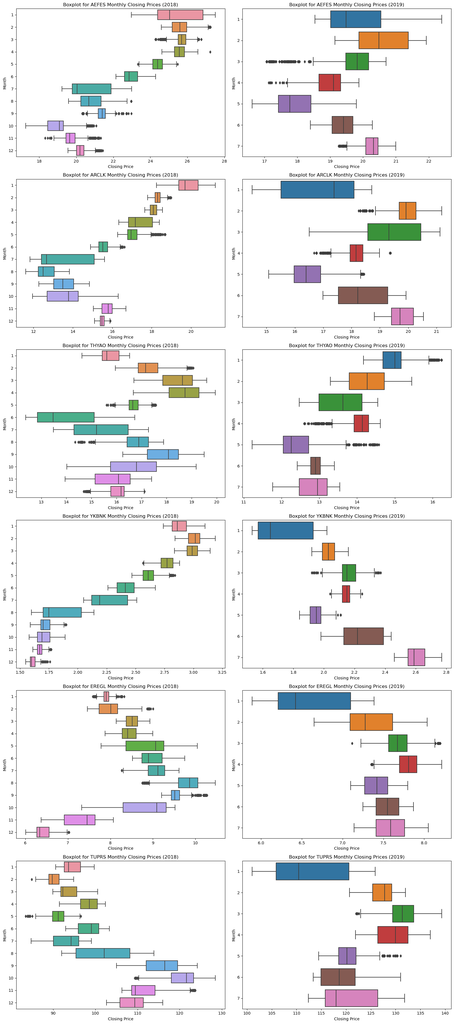

```python
import pandas as pd
import matplotlib.pyplot as plt
import seaborn as sns
a = pd.read_csv(f'/Users/ulucbaskurt/Desktop/all_ticks_wide.csv')
print(a.head())
print(a.dtypes)
a['timestamp'] = pd.to_datetime(a['timestamp'])
print(a.dtypes)

#we sort the values in terms of their time periods
a = a.sort_values(by='timestamp')


a = a.reset_index(drop=True)


print(a.columns)
print(a)

import pandas as pd
import matplotlib.pyplot as plt
import seaborn as sns
a = pd.read_csv(f'/Users/ulucbaskurt/Desktop/all_ticks_wide.csv')
print(a.head())
print(a.dtypes)
a['timestamp'] = pd.to_datetime(a['timestamp'])
print(a.dtypes)
a = a.sort_values(by='timestamp')


a = a.reset_index(drop=True)


print(a.columns)
print(a)

# Select each stock separately for the  analysis
selected_stocks = ['AEFES', 'ARCLK', 'THYAO', 'YKBNK', 'EREGL', 'TUPRS']

# Create a list to store information about outliers
outliers_info = []

# Create a figure object with separate rows for each stock and two columns for each year
fig, axes = plt.subplots(len(selected_stocks), 2, figsize=(16, 6 * len(selected_stocks)))

# Create more sophisticated box plots with highlighted outliers for each month and year
for i, stock_name in enumerate(selected_stocks):
    # Extract the data for the selected stock
    stock_data = a[['timestamp', stock_name]]

    # Set 'timestamp' as the index
    stock_data.set_index('timestamp', inplace=True)

    # Filter data for the years 2018 and 2019
    stock_data_2018 = stock_data[(stock_data.index >= '2018-01-01') & (stock_data.index <= '2018-12-31')]
    stock_data_2019 = stock_data[(stock_data.index >= '2019-01-01') & (stock_data.index <= '2019-12-31')]

    # Create a more sophisticated box plot for each stock for 2018
    ax = axes[i, 0]
    ax = sns.boxplot(x=stock_data_2018[stock_name], y=stock_data_2018.index.month, data=stock_data_2018, ax=ax, orient='h')
    ax.set_xlabel('Closing Price')
    ax.set_ylabel('Month')
    ax.set_title(f'Boxplot for {stock_name} Monthly Closing Prices (2018)')

    # Create a more sophisticated box plot for each stock for 2019
    ax = axes[i, 1]
    ax = sns.boxplot(x=stock_data_2019[stock_name], y=stock_data_2019.index.month, data=stock_data_2019, ax=ax, orient='h')
    ax.set_xlabel('Closing Price')
    ax.set_ylabel('Month')
    ax.set_title(f'Boxplot for {stock_name} Monthly Closing Prices (2019)')

    # Identify and annotate outliers for 2018
    Q1 = stock_data_2018[stock_name].quantile(0.25)
    Q3 = stock_data_2018[stock_name].quantile(0.75)
    IQR = Q3 - Q1
    outliers_2018 = stock_data_2018[(stock_data_2018[stock_name] < (Q1 - 1.5 * IQR)) | (stock_data_2018[stock_name] > (Q3 + 1.5 * IQR))]
    for date, outlier in outliers_2018.iterrows():
        outliers_info.append({
            'Stock': stock_name,
            'Year': 2018,
            'Month': date.month,
            'Outlier': outlier[stock_name]
        })

    # Identify and annotate outliers for 2019
    Q1 = stock_data_2019[stock_name].quantile(0.25)
    Q3 = stock_data_2019[stock_name].quantile(0.75)
    IQR = Q3 - Q1
    outliers_2019 = stock_data_2019[(stock_data_2019[stock_name] < (Q1 - 1.5 * IQR)) | (stock_data_2019[stock_name] > (Q3 + 1.5 * IQR))]
    for date, outlier in outliers_2019.iterrows():
        outliers_info.append({
            'Stock': stock_name,
            'Year': 2019,
            'Month': date.month,
            'Outlier': outlier[stock_name]
        })

# Adjust the layout
plt.tight_layout()

# Display information about outliers and potential reasons (you can fill this part)
for outlier in outliers_info:
    print(f"Outlier in {outlier['Stock']} for {outlier['Year']}-{outlier['Month']}: {outlier['Outlier']}")
    # Perform additional research or analysis to provide potential reasons for outliers

# Save or display the information as needed
plt.show()
```

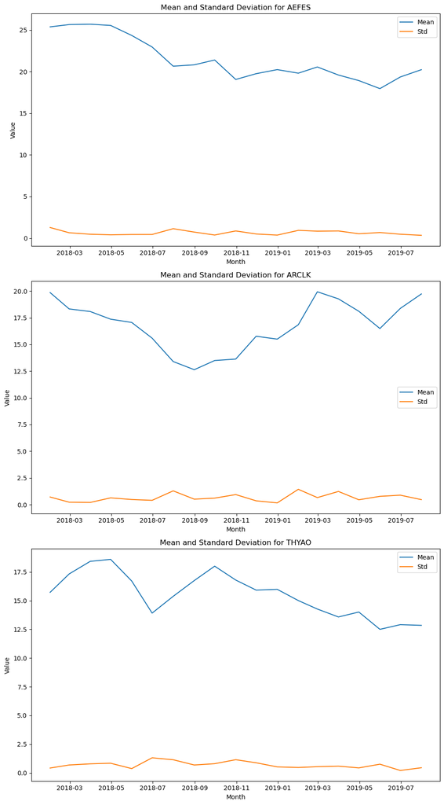

```python
import pandas as pd
import matplotlib.pyplot as plt
import seaborn as sns

# Read the CSV file
a = pd.read_csv('/Users/ulucbaskurt/Desktop/all_ticks_wide.csv')

# Convert the 'timestamp' column to datetime
a['timestamp'] = pd.to_datetime(a['timestamp'])

# Filter data for the years 2018 and 2019
start_date = '2018-01-01'
end_date = '2019-12-31'
a = a[(a['timestamp'] >= start_date) & (a['timestamp'] <= end_date)]

# Select the stocks for analysis
selected_stocks = ['AEFES', 'ARCLK', 'THYAO']

# Create a figure object for plotting
fig, axes = plt.subplots(len(selected_stocks), 1, figsize=(10, 6 * len(selected_stocks)))

# Iterate over each selected stock
for i, stock_name in enumerate(selected_stocks):
    stock_data = a[['timestamp', stock_name]]

    # Set 'timestamp' as the index
    stock_data.set_index('timestamp', inplace=True)

    # Group data by month and calculate mean and std
    monthly_stats = stock_data.resample('M').agg({stock_name: ['mean', 'std']})

    # Plot the mean and std for each stock
    ax = axes[i]
    ax.plot(monthly_stats.index, monthly_stats[stock_name]['mean'], label='Mean')
    ax.plot(monthly_stats.index, monthly_stats[stock_name]['std'], label='Std')
    ax.set_xlabel('Month')
    ax.set_ylabel('Value')
    ax.set_title(f'Mean and Standard Deviation for {stock_name}')
    ax.legend()

# Adjust the layout
plt.tight_layout()
plt.show()
```

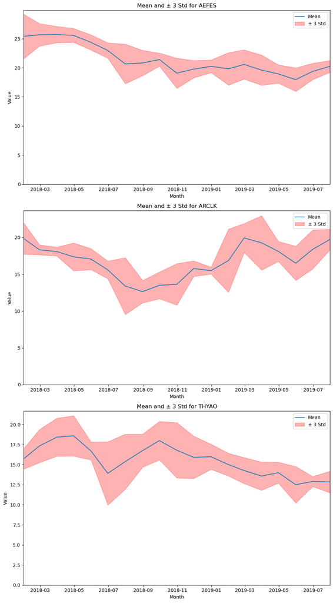

```python
import pandas as pd
import matplotlib.pyplot as plt
import seaborn as sns

# Read the CSV file
a = pd.read_csv('/Users/ulucbaskurt/Desktop/all_ticks_wide.csv')

# Convert the 'timestamp' column to datetime
a['timestamp'] = pd.to_datetime(a['timestamp'])

# Filter data for the years 2018 and 2019
start_date = '2018-01-01'
end_date = '2019-12-31'
a = a[(a['timestamp'] >= start_date) & (a['timestamp'] <= end_date)]

# Select the stocks for analysis
selected_stocks = ['AEFES', 'ARCLK', 'THYAO']

# Create a figure object for plotting
fig, axes = plt.subplots(len(selected_stocks), 1, figsize=(10, 6 * len(selected_stocks)))

# Iterate over each selected stock
for i, stock_name in enumerate(selected_stocks):
    stock_data = a[['timestamp', stock_name]]

    # Set 'timestamp' as the index
    stock_data.set_index('timestamp', inplace=True)

    # Group data by month and calculate mean and std
    monthly_stats = stock_data.resample('M').agg({stock_name: ['mean', 'std']})

    # Calculate +/- 3 std lines
    monthly_stats['Lower Bound'] = monthly_stats[stock_name]['mean'] - 3 * monthly_stats[stock_name]['std']
    monthly_stats['Upper Bound'] = monthly_stats[stock_name]['mean'] + 3 * monthly_stats[stock_name]['std']

    # Plot the mean and std for each stock
    ax = axes[i]
    ax.plot(monthly_stats.index, monthly_stats[stock_name]['mean'], label='Mean')
    ax.fill_between(monthly_stats.index, monthly_stats['Lower Bound'], monthly_stats['Upper Bound'], alpha=0.3, color='red', label='± 3 Std')
    ax.set_xlabel('Month')
    ax.set_ylabel('Value')
    ax.set_title(f'Mean and ± 3 Std for {stock_name}')
    ax.legend()

    # Set y-axis to start from 0
    ax.set_ylim(bottom=0)

# Set x-axis limits to cover the entire interval
for ax in axes:
    ax.set_xlim(monthly_stats.index[0], monthly_stats.index[-1])

# Adjust the layout
plt.tight_layout()
plt.show()
```

```python
# general info // quick overview about the data from the pandas command .describe()

# Assuming you have a DataFrame named 'a' with the stock data

# Filter the DataFrame for the 2-year period (2018-2019) and the three stocks
start_date = '2018-01-01'
end_date = '2019-12-31'
selected_stocks = ['AEFES', 'ARCLK', 'THYAO']

# Filter rows based on the date range
filtered_data = a[(a['timestamp'] >= start_date) & (a['timestamp'] <= end_date)]

# Select columns (stocks) using the 'selected_stocks' list
filtered_data = filtered_data[selected_stocks]

# Use .describe() to get summary statistics for the filtered data
statistics = filtered_data.describe()

print(statistics)
```

```
              AEFES         ARCLK         THYAO
count  11947.000000  12027.000000  12078.000000
mean      21.491549     16.792920     15.551490
std        2.652035      2.346334      1.980118
min       16.623800     11.610000     11.220000
25%       19.488600     15.350000     13.970000
50%       20.482500     17.010000     15.650000
75%       24.120900     18.406800     17.010000
max       27.514600     21.234900     19.950000
```

```python
# formulation on how to calculate approximate number of data points for each stock price in 2 years period

365*5/7*8*4*2

# we then compare it with the count amount in describe command
# we see that approximately a quarter of data for each stock is missing but it is subject to change in every year
```

```
16685.714285714286
```

Now we add the Google Trends search data outputs for the stock names in order to make inferences:

Google Trends data for AEFES search amounts:

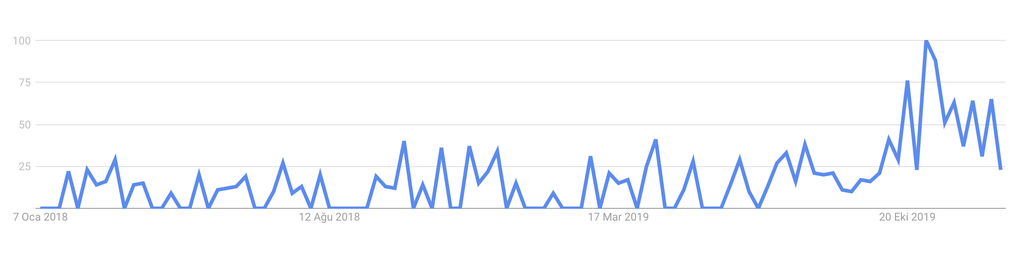

Google Trends data for ARCLK search amounts:

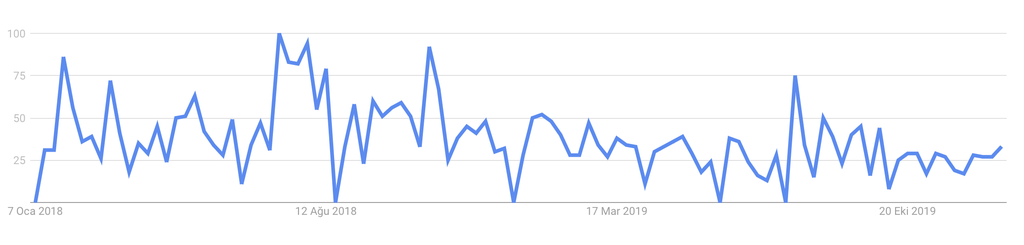

Google Trends data for THYAO search amounts:

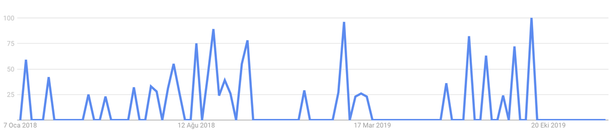

Google Trends data for EREGL search amounts

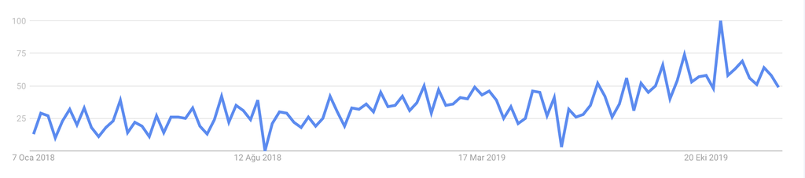

Google Trends data for YKBNK search amounts:

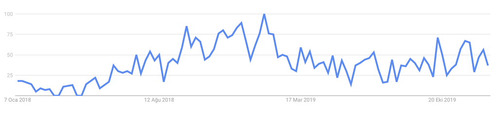

Google Trends data for TUPRS search amounts:

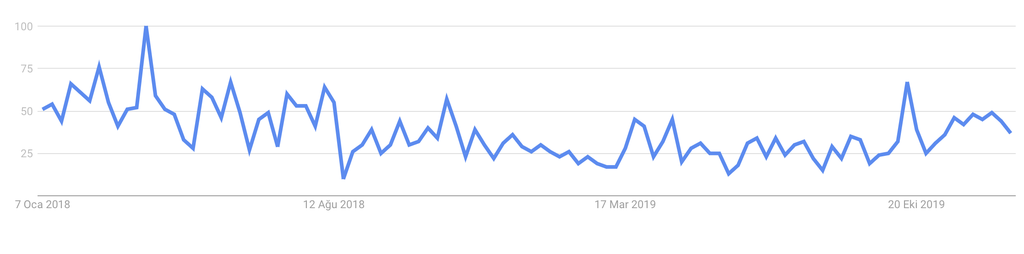